# Verifying Theoretical Equations

Haoda Song, Bretho Danzy, and Yuqi Zhang

12 March, 2020

## Executive Summary

We sought to verify two theoretical formulas used in manufacturing engineering to measure roughness and diametral error. Using empirical data collected in an MME 231 course at Miami University we are given a dataset with 54 observations: 51 roughness measurements and 16 diametral error measurement taken on 3 regions (Region 1: Chuck-end, Region 2: Mid-workpiece, Region 3: Tip-end). Implimenting linear regression methods we used this data to build no-intercept models that would best emmulate the structure given in the theoretical formulas. Once these models were computed we compared these *predicted coefficients* to those given in the as *truth coefficents* in the theoretical formula. We then calcuated a 95% confidence interval to see if it would capture are *truth coefficient* in said interval.

```r
# create columns
names <- c("Roughness",
           "Diametral Error, Region 1",
           "Diametral Error, Region 2",
           "Diametral Error, Region 3")
truth <- c(1.0272,
           rep(0.1706667,3))
preds <- c(coefficients(lme_model)[1,1],
           coefficients(diametral_error_lm)[[1]],
           coefficients(diametral_error_lm)[[2]],
           coefficients(diametral_error_lm)[[3]])
c_low <- c(intervals(object = lme_model, which = "fixed")$fixed[1],
           confint(object = diametral_error_lm)[[1]],
           confint(object = diametral_error_lm)[[2]],
           confint(object = diametral_error_lm)[[3]])
c_his <- c(intervals(object = lme_model, which = "fixed")$fixed[3],
           confint(object = diametral_error_lm)[[4]],
           confint(object = diametral_error_lm)[[5]],
           confint(object = diametral_error_lm)[[6]])

# create tibble put it in kable
tibble("Experiments" = names, "True Coeff." = truth, "Pred. Coeff." = preds,
       "Lower Bound" = c_low, "Upper Bound" = c_his) %>%
  kable(caption = "Table 1: A brief chart comparing coefficients from theoretical formulas and predicted formulas from MME 231 data.") %>%
  add_header_above(header = c(" " = 3, "95% Confidence Interval" = 2)) %>%
  kable_styling(full_width = TRUE, bootstrap_options = 'striped')
```

Table 1: A brief chart comparing coefficients from theoretical formulas and predicted formulas from MME 231 data.

| Experiments | True Coeff. | Pred. Coeff. | 95% Confidence Interval Lower Bound | 95% Confidence Interval Upper Bound |
| --- | --- | --- | --- | --- |
| Roughness | 1.0272000 | 0.4562809 | 0.3501820 | 0.5623797 |
| Diametral Error, Region 1 | 0.1706667 | 0.3035904 | -1.6741763 | 2.2813570 |
| Diametral Error, Region 2 | 0.1706667 | 0.1843442 | -0.6494338 | 1.0181222 |
| Diametral Error, Region 3 | 0.1706667 | 0.0173144 | -0.3017660 | 0.3363949 |

## Introduction

### Motivation

When given a theoretical equations we often see the information gleaned from them as the truth. And these will hold true when certain assumptions and ideal conditions are met. However, will these theoretical equations be shown to be self evident if we were to reverse engineer them? That is what we set out to solve in this project.

### Background

We are given to theoretical formulas to verify:

#### Roughness Formula

$$\text{Roughness} = 0.0321\cdot \frac{(\text{Feed per rev})^2}{\text{(Tool nose radius)}}, \hspace{2mm}\text{where (Tool nose radius) = 1/32}$$

#### Diametral Error Formula

$$\text{Diametral Error} =
\frac{128}{3} \cdot
\frac{Y\cdot(\text{Radial Depth of Cut})\cdot
(\text{Feed per rev})\cdot (\text{Overhang})^3}
{E\cdot (\text{Workpiece Diameter})^4}
, \hspace{2mm}\text{where }
\left\{
\begin{array}{l}
E = 10,000,000\\
Y = 40,000\\
\end{array}
\right.$$

We want to show this with the given data.

#### Data Structure

The raw data we recieved initial had 54 observations and 21 variables. Here is transposed sample of the first six observations.

```r
# filter the data
raw_sample <- t(head(raw_data, 6))[1:21,]
# organize data
organized <- bind_cols(
  "Variables" = as.character(unlist(dimnames(raw_sample)[1])),
  "Obs. 1" = raw_sample[,1], "Obs. 2" = raw_sample[,2],
  "Obs. 3" = raw_sample[,3], "Obs. 4" = raw_sample[,4],
  "Obs. 5" = raw_sample[,5], "Obs. 6" = raw_sample[,6])

# make a kable
organized %>%
  kable(caption = "Table 2: A sample of the raw data.") %>%
  kable_styling(c("bordered")) %>%
  add_header_above(c(" " = 1, "Group 1" = 3, "Group 2" = 3))
```

Table 2: A sample of the raw data.

| Variables | Group 1 Obs. 1 | Group 1 Obs. 2 | Group 1 Obs. 3 | Group 2 Obs. 4 | Group 2 Obs. 5 | Group 2 Obs. 6 |
| --- | --- | --- | --- | --- | --- | --- |
| Faced Diameter (in) | 1.319 | 1.319 | 1.319 | 1.398 | 1.398 | 1.398 |
| f (in/rev) | 0.016 | 0.016 | 0.016 | 0.016 | 0.016 | 0.016 |
| DOC (in) | 0.01 | 0.01 | 0.01 | 0.02 | 0.02 | 0.02 |
| Rotation Speed (RPM) | 85 | 260 | 370 | 85 | 260 | 370 |
| Cutting vel V (ft/min) | 29.35164 | 89.78148 | 127.76596 | 31.10962 | 95.15884 | 135.41835 |
| From [approx distance] (close to the chuck) | 4.678 | 2.732 | 0.614 | 4.233 | 2.346 | 0.354 |
| to [approx distance] (close to the tip) | 6.6130 | 4.7530 | 2.7075 | 6.2560 | 4.5670 | 2.6730 |
| Roughness 1 (micro-in) | 228 | 200 | 200 | 339 | 176 | 297 |
| Roughness 2 | 238 | 212 | 199 | 349 | 184 | 284 |
| Roughness 3 | 232 | 209 | 221 | 343 | 179 | 294 |
| Tip-end diameter 1 (in) | 1.29885 | 1.30080 | 1.29960 | 1.19450 | 1.18900 | 1.18600 |
| Tip-end diameter 2 | 1.29880 | 1.30060 | 1.30005 | 1.19500 | 1.19000 | 1.18700 |
| Tip-end diameter 3 | 1.29855 | 1.30095 | 1.29965 | 1.19520 | 1.19030 | 1.18720 |
| Chuck end diameter 1 | 1.29870 | 1.29995 | 1.29855 | 1.18900 | 1.18410 | 1.18800 |
| Chuck end diameter 2 | 1.29855 | 1.29935 | 1.30005 | 1.19000 | 1.18430 | 1.18800 |
| Chuck end diameter 3 | 1.29835 | 1.29885 | 1.29945 | 1.19020 | 1.18300 | 1.18800 |
| Roughness (micro-in) | 232.6667 | 207.0000 | 206.6667 | 343.6667 | 179.6667 | 291.6667 |
| Cutting force (lbs) | 20.10619 | 20.10619 | 20.10619 | 40.21239 | 40.21239 | 40.21239 |
| Power (lb*ft/min) | 590.1497 | 1805.1638 | 2568.8870 | 1250.9921 | 3826.5641 | 5445.4950 |
| Tip deflection (in) | 1.304533e-03 | 4.843541e-04 | 8.952924e-05 | 2.208919e-03 | 8.593747e-04 | 1.723004e-04 |
| Chuck-End Deflection (in) | 4.617854e-04 | 9.198173e-05 | 1.044154e-06 | 6.842807e-04 | 1.164859e-04 | 4.002205e-07 |

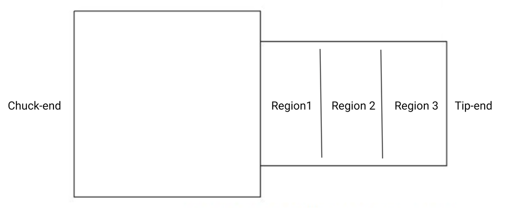

Graphic 1: Workpiece Diagram with denoted regions.

After we organized the data we had to address missingness in our data. That left us with a dataset with 51 observation for roughness and 3 regions of 16 groups or 48 observations for diametral error. We show a short sample below.

```r
head(clean_data, 6) %>%
  kable(caption = "Table 3: A sample of the cleaned data.") %>%
  kable_styling(c("bordered"))
```

Table 3: A sample of the cleaned data.

| region | workpiece_id | diametral_error | roughness | diametral_error_predictor | roughness_predictor |
| --- | --- | --- | --- | --- | --- |
| 3 | 1 | -0.00015 | 0.0002327 | 0.0054115 | 0.000256 |
| 2 | 1 | 0.00180 | 0.0002070 | 0.0010779 | 0.000256 |
| 1 | 1 | 0.00060 | 0.0002067 | 0.0000122 | 0.000256 |
| 3 | 2 | -0.16350 | 0.0003437 | 0.0063543 | 0.000256 |
| 2 | 2 | -0.16900 | 0.0001797 | 0.0010817 | 0.000256 |
| 1 | 2 | -0.17200 | 0.0002917 | 0.0000037 | 0.000256 |

### Data Disctionary

The data we use to verify these equations have 42 observations with the following variables:  
**region**: three regions on the workpiece. Numbered with respect to distance from chuck. 1 being the closest to chuck and 3 being the farthest. Region 1 = Chuck-end. Region 2 = Middle. Region 3 = Tip-end.  
**workpiece_id**: the workpiece or “group” the observation belongs to.  
**diametral_error**: diametral error calculated.  
**roughness**: roughness calculated.  
**diametral_error_predictor**: all non-constants in diametral error formula.  
**roughness_predictor**: all non-constants in roughness formula

## Methods

We approached the verification of these two equations through the comparison of coefficients via simple linear regressions and linear mixed effect model, which would be explained later. We reduced the problem by merging all giving constants into the coefficient resulting in the two following equations:

#### Simplified Roughness Formula

$$\text{Roughness} = \underbrace{1.0272}_{\text{Truth Coeff.}}
\cdot (\text{Roughness Predictor})$$

#### Simplified Diametral Error Formula

$$\text{Diametral Error} =
\underbrace{0.1706667}_{\text{Truth Coeff.}}
\cdot (\text{Diametral Error Predictor})$$

### Modeling

The models we used to estimate the coeficients are the following models:

#### Roughness:

##### Simple Linear Regression

$$\text{Roughness}_{i} = \beta
\cdot (\text{Roughness Predictor}_{i}) +
\epsilon_{i}$$
As we claimed in Data part, we omitted missing observations and outliers and group all observations as 16 groups because, in the diametral error model, we don’t have one empirical measurement for each region so we averaged the chuck and tip end diametral error for each region. Therefore, we consider if there is an effect caused by grouping observations so that we use linear mixed effect model to test it.

##### Linear Mixed Effect Model

$$\text{Roughness}_{ij} = \beta
\cdot (\text{Roughness Predictor}_{ij}) +
\epsilon_{ij}+
\gamma_{i}$$

Where $i$ represents group i and $j$ represents measurement j in group i; $\epsilon_{ij}$ represents residuals and follows the identically indenpendent nomarl distribution $~N(0,\sigma^2)$ $\gamma_{i}$ represents “random effect”, which is an effect caused by grouping; $\beta \cdot \text{Roughness Predictor}_{ij}$ represents “fixed effect”, which is an effect caused by roughness predictor. More information about Linear Mixed Effect Model could be found in “Appendix”.

#### Diamtral Error:

##### Simple Linear Regression in Each Zone

$$\text{Diametral Error}_{ij} = \beta
\cdot (\text{Diametral Error}_{ij}*\text{Region}_{j}) +
\epsilon_{ij}$$
Where $i$ represents ith obervation, $j$ represnts jth group, in this case we have j=1,2,3 due to three zones.

## Results

### Exploratory Data Analysis

For roughness equation, we don’t have concern about outliers, therefore the plot is the same as our final result plot in “Result” part. And we would explain our findings and analysis later.

For diametral error equation, we have some unusual points which are far away from others as the belowing graph shows:

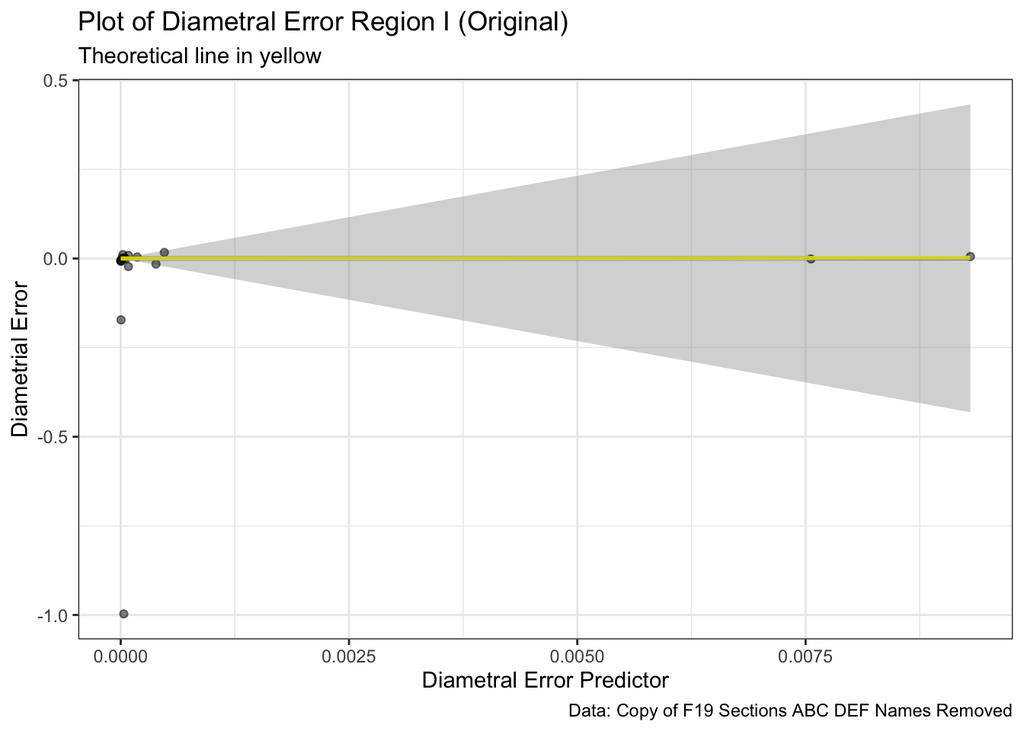

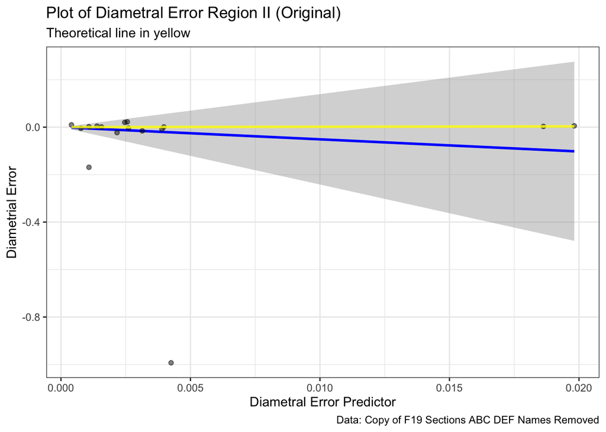

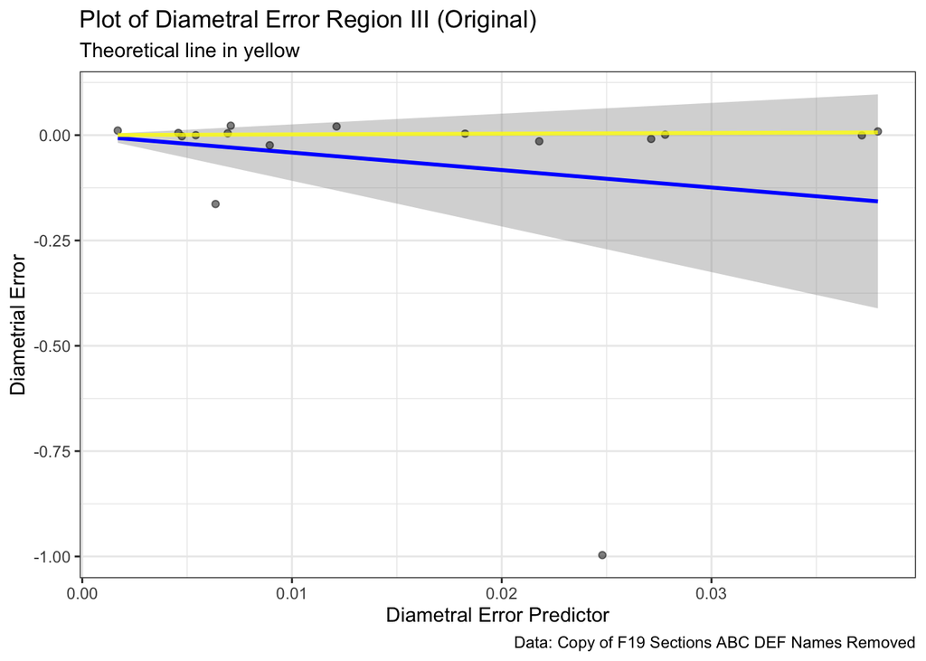

### Verify Roughness Equation

```
##                         2.5 %    97.5 %
## roughness_predictor 0.3934365 0.5191253
```

The above confidence interval, (0.3934365, 0.5191253), for the coefficient of roughness predictor shows that we have strong confidence our estimated coefficient would be in this range based on the given data. However, our theoretical coefficient, which calculated by roughness equation, should be 1.0272. This value falls outside of our confidence interval means that we maybe unable to verify the roughness equation.

(Relevant output of the model: In our analysis, the p value which is around zero means we have strong evidence the coefficient of “Roughness Predictor” is greater than 0. R-squared values which are around 0.81 means that our model explains the “Roughness” pretty well. We also have a small standard error which means our uncertainty of estimation is small.)

One concern is that if we’re going to do a CI, it assumes that the data are independent, but there is going to clearly be a lack of independence due to the groups.

And there are two ways to solve this problem, simplify the data so that the independent assumption is reasonable and build a complex model. We could not simplify the data because we are trying to verify the equation by the given data and each observations is collected by a designed specific experiment.

Therefore, we would like to build a linear mixed effect model which counted grouping effect and roughness predictor effect simultaneously.

```
## Approximate 95% confidence intervals
##
##  Fixed effects:
##                        lower      est.     upper
## roughness_predictor 0.350182 0.4562809 0.5623797
## attr(,"label")
## [1] "Fixed effects:"
```

However, after we considered the grouping effect, the confidence interval of the coefficient, (0.350182, 0.5623797), doesn’t change a lot and 1.0272 still doesn’t fall in this interval. Therefore, we should have strong confidence to conclude that we are unable to verify the roughness equation using given experimental data.

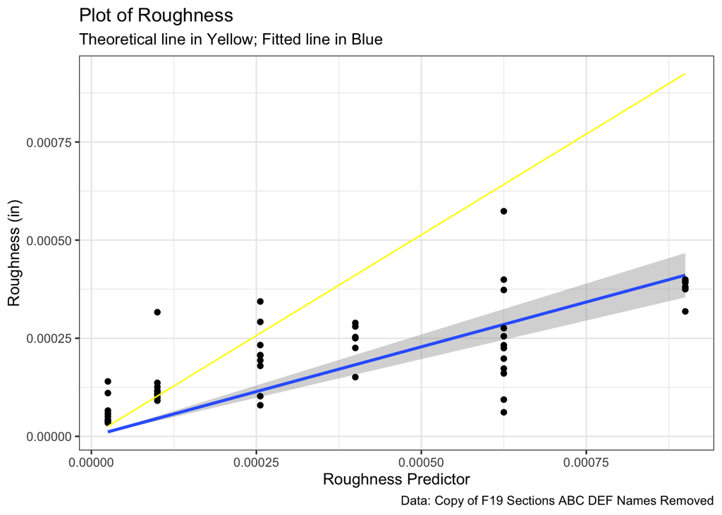

In the above plot, each dot represents one estimated roughness based on the given data compared to the theoretical roughness. We can see that the slope of the fitted regression line (blue) based on the roughness model is different than the slope of the theoretical line (yellow) based on the roughness equation.

In our analysis, there are no outliers, the grey shadow area represents our confidence interval for the coefficient of roughness predictor. It means if the theoretical line falls in the grey shadow area, we should have confidence that our slope of fitted regression line is reasonable to be closed to the slope of theoretical line. And it also means our estimated coefficient is very closed to our theoretical coefficient in the given equation. However, it is obvious that the theoretical roughness line (yellow) doesn’t fall in the grey shadow area, which means we fail to verify the roughness equation.

### Verify Diametral Error Equation

#### Region I

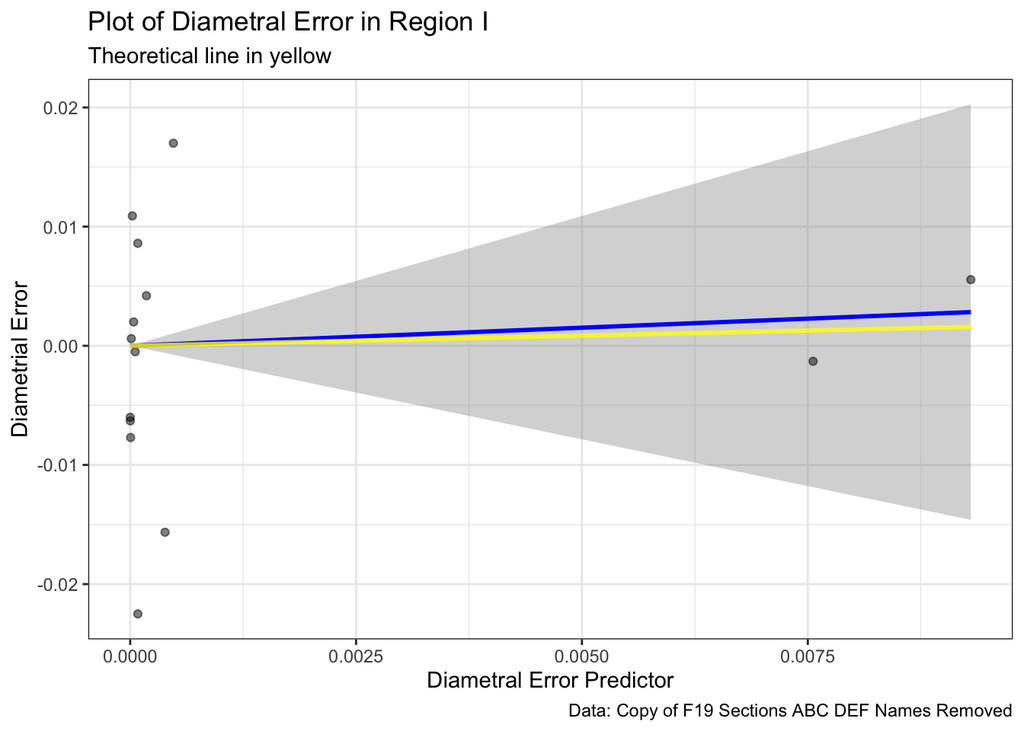

#### Region II

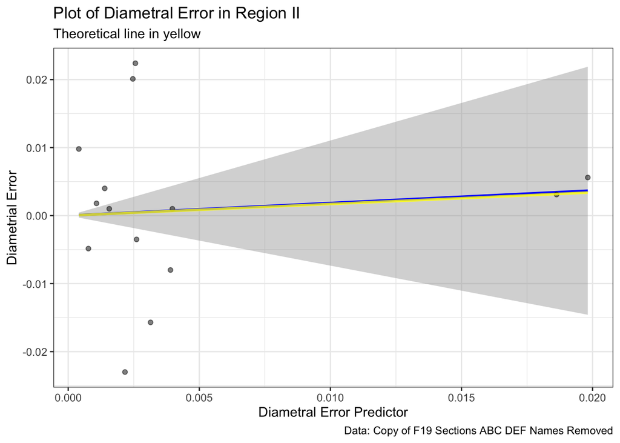

As you can see, there exists two points in region I and II which are far away from other points in the direction of “diametral error predictor” (x-axis). We could consider these points as high leverage points in statistics (see Appendix about the term, “leverage”). We believe our estimated coefficient (blue line) which is an reasonable good estimation of theoretical parameter (yellow line). In graph, it is shown as blue lines is very closed to yellow line in different regions. The reason that we have some high leverage points is that the fact that the experiment was not truly designed to properly evaluate these theoretical equations. Even if we removed these high leverage points, result and conclusion would be the same as what we found. (Please see Appendix)

#### Region III

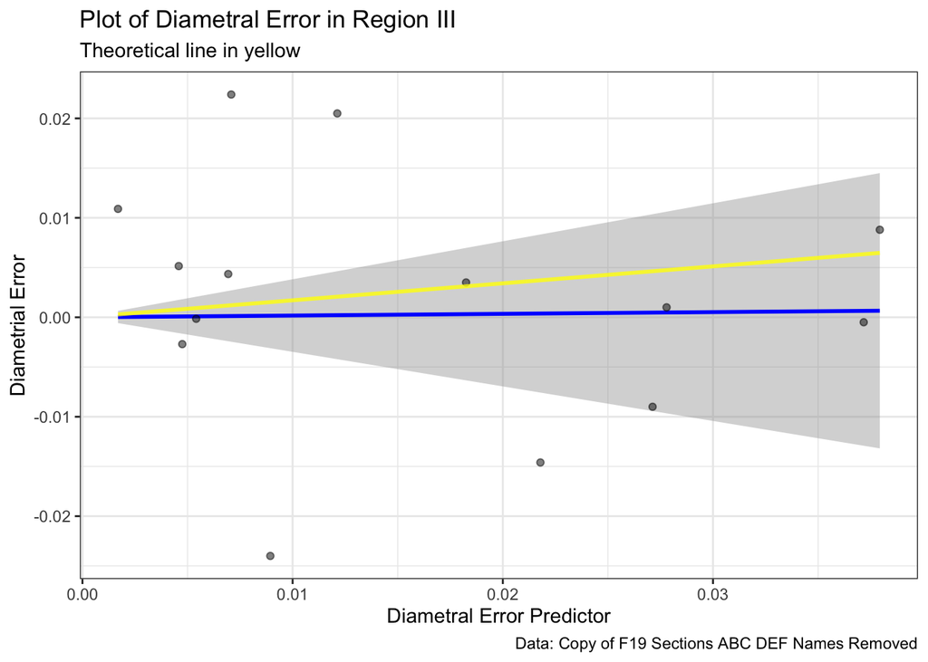

```
## [1] 0.007846729
```

```
## [1] -0.06847275
```

However, the main concern is from small R-squares–R square: 0.0078 and Adjusted R square:-0.068, of our model, although we have pretty good form of the model which matched the form of equation perfectly. (The R square is the percentage of the response variable variation that a linear model explains. More information can be found in Appendix). We have pretty low R-squared approaching zero which means our model based on the data predicts diametral error poorly (The summary output is attached in Appendix).

Therefore, all conclusions based on this model are unreasonable. We still fail to verify the diametral error equation using the given experimental data.

## Discussion

### Conclusion

In this project, we verify the given two equations. Through the process of verify the equation, build several models and get the most accurate model at last. Implimenting linear regression methods we used this data to build no-intercept models that would best emmulate the structure given in the theoretical formulas. Once these models were built we compared these *predicted coefficients* to those given in the as *truth coefficents* in the theoretical formula. We then calcuated a 95% confidence interval to see if it would capture are *truth coefficient* in said interval.

For the diametral error equation, we built simple linear regression without intercept in each region. At first, we separated the workpiece into three zones as the clients’ experiment designed and made scatterplots in each region.

Based on our visualization, we found outliers in all three regions and high leverage points in region I and II (How we define outliers and leverage points could be found in both “Data Disctionary” and “Appendix”). We removed outliers and kept high leverage points. These high leverage points doesn’t quitely affect our result of model analysis (The output before and after removing high leverage points could be found in “Appendix”). And we believe this happened because the experiment was not designed to test the theoretical equations. We found the theoretical diametral error truth coefficient fell within the interval of the confidence interval, which means we should consider the estimation of coefficient based on the data is very closed to the coefficient of the theoretical equation. However, we have too small R squares. It means the model based on the data predicts diametral error poorly and all conclusions based on this model are unreasonable. We still fail to verify our diametral error equation based on the given experimental data.

### Concerns

We have small sample to verify the equations. Only 54 observations are given and we only use 42 observations after we remove several outliers. The thoeretical equation may work when there exists many different observations and spreads out widely.

Another issue is about high leverage points. We suggest clients may design the experiment for the purpose that to verify the theoretical equations. If observations could be independent without grouping, results of analysis might change.

Frequentist statistics is not really set up to test if a parameter is the same as a particular value. Instead, it is set up to reject the hypothesis that the parameter is a certain value. So trying to verify if the fitted equation is the same as the theoretical equation isn’t natural for us. But we did the best we can.

## References

R Core Team (2018). R: A language and environment for statistical computing. R Foundation for Statistical Computing, Vienna, Austria. URL https://www.R-project.org/.

Hadley Wickham (2017), package ‘tidyverse’, R package version 1.3.0. https://CRAN.R-project.org/package=tidyverse

Hadley Wickham, Winston Chang, Lionel Henry, Thomas Lin Pedersen, Kohske Takahashi, Claus Wilke, Kara Woo, Hiroaki Yutani (2019), package ‘ggplot2’, R package version 3.2.1, https://cran.r-project.org/web/packages/ggplot2/index.html

Hadley Wickham, Jennifer Bryan, RStudio, Marcin Kalicinski, Komarov Valery , Christophe Leitienne, Bob Colbert, David Hoerl, Evan Miller(2019),package ‘readxl’, R package version 1.3.1, https://cran.r-project.org/web/packages/readxl/

José Pinheiro, Douglas Bates, Saikat DebRoy, Deepayan Sarkar, Siem Heisterkamp, Bert Van Willigen, R-core, 03/04/2020, package ‘nlme’, R package version 3.1-145,https://cran.r-project.org/web/packages/nlme/

Hao Zhu, Thomas Travison, Timothy Tsai, Will Beasley, Yihui Xie, GuangChuang Yu , Stéphane Laurent, Rob Shepherd, Yoni Sidi, Brian Salzer, George Gui, Yeliang Fan, Duncan Murdoch, 03/16/2019, package ‘kableExtra’, R package version 1.1.0, https://cran.r-project.org/web/packages/kableExtra/

HOME. (n.d.). Retrieved from https://stats.idre.ucla.edu/other/mult-pkg/introduction-to-linear-mixed-models/ 9.1 - Distinction Between Outliers and High Leverage Observations. (n.d.). Retrieved from https://online.stat.psu.edu/stat462/node/170/

Fuqua School of Business. (n.d.). Retrieved from https://people.duke.edu/~rnau/rsquared.htm

Data source: Meet Google Drive – One place for all your files. (n.d.). Retrieved from https://drive.google.com/file/d/1s_OcuRFQD532Dsh9OP0H99rVGPwxxLaS/view

Model Source: Applied Linear Statistical Model (Fifth edition) Micheal H. Kutner

## Appendix

### Linear Mixed Effect Model

https://stats.idre.ucla.edu/other/mult-pkg/introduction-to-linear-mixed-models/

### Outlier and high Leverage

https://online.stat.psu.edu/stat462/node/170/

### R squared and adjusted R-squared

https://people.duke.edu/~rnau/rsquared.htm

### Summary Output (Used in analysis)

```
##
## Call:
## lm(formula = diametral_formula, data = clean_data_diametral)
##
## Residuals:
##        Min         1Q     Median         3Q        Max
## -0.0241548 -0.0057480  0.0005576  0.0048605  0.0222774
##
## Coefficients:
##                                   Estimate Std. Error t value Pr(>|t|)
## diametral_error_predictor:region1  0.30359    0.97779   0.310    0.758
## diametral_error_predictor:region2  0.18434    0.41221   0.447    0.657
## diametral_error_predictor:region3  0.01731    0.15775   0.110    0.913
##
## Residual standard error: 0.01174 on 39 degrees of freedom
## Multiple R-squared:  0.007847,   Adjusted R-squared:  -0.06847
## F-statistic: 0.1028 on 3 and 39 DF,  p-value: 0.9579
```

### Summary Output and Plots (Removed high leverage points)

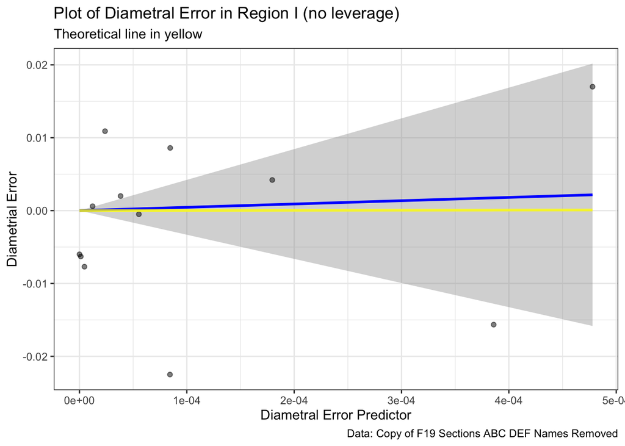

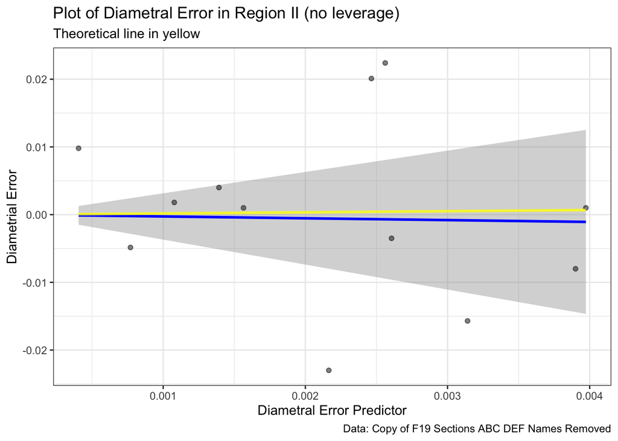

```
##
## Call:
## lm(formula = diametral_error ~ diametral_error_predictor:region +
##     0, data = no_leverage_data)
##
## Residuals:
##        Min         1Q     Median         3Q        Max
## -0.0241548 -0.0062291  0.0009833  0.0073750  0.0230909
##
## Coefficients:
##                                   Estimate Std. Error t value Pr(>|t|)
## diametral_error_predictor:region1  4.52917   18.83494   0.240    0.811
## diametral_error_predictor:region2 -0.26968    1.46125  -0.185    0.855
## diametral_error_predictor:region3  0.01731    0.16580   0.104    0.917
##
## Residual standard error: 0.01234 on 35 degrees of freedom
## Multiple R-squared:  0.002928,   Adjusted R-squared:  -0.08254
## F-statistic: 0.03426 on 3 and 35 DF,  p-value: 0.9913
```

Our main concern isn’t solved. We still have small R squares, even less than our previous model without remove high leverage points due to remove observations.

### Code Used

```r
# load necessary libraries
library(tidyverse)        # how R works
library(ggplot2)          # how plotting in R works
library(readxl)           # how R reads .xlsx's
library(nlme)             # how R does mixed linear models
library(kableExtra)       # add-on to knitr
library(knitr)            # producing nice html tables in R

# load the data
raw_data <- read_excel("/Users/stephen/Desktop/STA475/Capstone\ Group\ Project/Copy\ of\ F19\ Sections\ ABC\ DEF\ Names\ Removed.xlsx")

# clean the data
clean_data <- raw_data %>%
  # create a sorting variables
  mutate(row_id = 1:54, workpiece_id = rep(1:18, each = 3)) %>%
  # group by rows to perform row-wise calculations
  group_by(row_id) %>%
  # perform row-wise calculations
  mutate(
    # formula for theoretical turned diameter
    turned_ideal = `Faced Diameter (in)` - 2*`DOC (in)`,
    # average chuck diameter measurements
    diameter_chuck = mean(`Chuck end diameter 1`,
                          `Chuck end diameter 2`,
                          `Chuck end diameter 3`),
    # average tip diameter measurements
    diameter_tip = mean(`Tip-end diameter 1 (in)`,
                        `Tip-end diameter 2`,
                        `Tip-end diameter 3`),
    # average two previous diameter measurements
    diameter_mean = mean(diameter_tip,diameter_chuck),
    # formula for diametral error (empirical)
    diametral_error = diameter_mean - turned_ideal,
    # average overhang distance
    overhang = mean(`From [approx distance] (close to  the chuck)`,
                    `to [approx distance] (close to the tip)`)) %>%
  # ungroup by row_id
  ungroup() %>%
  # clean up variable names & calculate predictors
  mutate(feed_per_rev = `f (in/rev)`,
         roughness = `Roughness (micro-in)`*.000001,
         depth_of_cut = `DOC (in)`,
         workpiece_diameter = `Faced Diameter (in)`,
         roughness_predictor = feed_per_rev^2,
         diametral_error_predictor =
           (depth_of_cut*feed_per_rev*overhang^3)/workpiece_diameter^4) %>%
  # group by workpiece_id to sort by overhang distance and denote region id
  group_by(workpiece_id) %>%
  # develop region id system
  mutate(region = as.character(order(overhang,decreasing = F))) %>%
  ungroup() %>%
  # select variables to keep
  select(region, workpiece_id,diametral_error,roughness,
         diametral_error_predictor, roughness_predictor)

# filter data for clean_data_roughness
clean_data_roughness <-
  clean_data %>%
  filter(!is.na(roughness))

clean_data_diametral <-
  clean_data %>%
  filter(!is.na(diametral_error))%>%
  filter(diametral_error > -0.1)

# build regression models
# model form (no intercept) - roughness
  roughness_formula <- formula(roughness ~ 0 + roughness_predictor)

# model form (no intercept) - diametral error
  diametral_formula <- formula(diametral_error ~ 0 +
                                 diametral_error_predictor:region)

# mixed effect model - roughness
  lme_model <- lme(fixed = roughness_formula,
      data = clean_data_roughness,
      random = ~ 1 | workpiece_id,
      correlation =
        corGaus(form = ~ 1 | workpiece_id))

# linear model - diametral error
  diametral_error_lm <- lm(formula = diametral_formula,
                 data = clean_data_diametral)
# create columns
names <- c("Roughness",
           "Diametral Error, Region 1",
           "Diametral Error, Region 2",
           "Diametral Error, Region 3")
truth <- c(1.0272,
           rep(0.1706667,3))
preds <- c(coefficients(lme_model)[1,1],
           coefficients(diametral_error_lm)[[1]],
           coefficients(diametral_error_lm)[[2]],
           coefficients(diametral_error_lm)[[3]])
c_low <- c(intervals(object = lme_model, which = "fixed")$fixed[1],
           confint(object = diametral_error_lm)[[1]],
           confint(object = diametral_error_lm)[[2]],
           confint(object = diametral_error_lm)[[3]])
c_his <- c(intervals(object = lme_model, which = "fixed")$fixed[3],
           confint(object = diametral_error_lm)[[4]],
           confint(object = diametral_error_lm)[[5]],
           confint(object = diametral_error_lm)[[6]])

# create tibble put it in kable
tibble("Experiments" = names, "True Coeff." = truth, "Pred. Coeff." = preds,
       "Lower Bound" = c_low, "Upper Bound" = c_his) %>%
  kable(caption = "Table 1: A brief chart comparing coefficients from theoretical formulas and predicted formulas from MME 231 data.") %>%
  add_header_above(header = c(" " = 3, "95% Confidence Interval" = 2)) %>%
  kable_styling(full_width = TRUE, bootstrap_options = 'striped')
# filter the data
raw_sample <- t(head(raw_data, 6))[1:21,]
# organize data
organized <- bind_cols(
  "Variables" = as.character(unlist(dimnames(raw_sample)[1])),
  "Obs. 1" = raw_sample[,1], "Obs. 2" = raw_sample[,2],
  "Obs. 3" = raw_sample[,3], "Obs. 4" = raw_sample[,4],
  "Obs. 5" = raw_sample[,5], "Obs. 6" = raw_sample[,6])

# make a kable
organized %>%
  kable(caption = "Table 2: A sample of the raw data.") %>%
  kable_styling(c("bordered")) %>%
  add_header_above(c(" " = 1, "Group 1" = 3, "Group 2" = 3))
head(clean_data, 6) %>%
  kable(caption = "Table 3: A sample of the cleaned data.") %>%
  kable_styling(c("bordered"))

##EDA
# plot region I
ggplot() +
  geom_smooth(aes(x = diametral_error_predictor, y = diametral_error),
              data = filter(clean_data, region == "1"),
              method = "lm", formula = y ~ x +0,
              color = "blue") +
    geom_point(aes(x = diametral_error_predictor, y = diametral_error),
              data = filter(clean_data, region == "1"),
             color = "black",
             alpha = .5) +
  geom_line(aes(x = diametral_error_predictor, y = 0.1706667*diametral_error_predictor),
            data =  filter(clean_data, region == "1"),
            color = "yellow",
            size = 1,
            alpha = .8) +
  labs(title = "Plot of Diametral Error Region I (Original)",
       subtitle = "Theoretical line in yellow",
       caption = "Data: Copy of F19 Sections ABC DEF Names Removed",
       x = "Diametral Error Predictor",
       y = "Diametrial Error") +
  theme_bw()
```

```r
# plot region II
ggplot() +
  geom_smooth(aes(x = diametral_error_predictor, y = diametral_error),
              data = filter(clean_data, region == "2"),
              method = "lm", formula = y ~ x +0,
              color = "blue") +
    geom_point(aes(x = diametral_error_predictor, y = diametral_error),
              data = filter(clean_data, region == "2"),
             color = "black",
             alpha = .5) +
  geom_line(aes(x = diametral_error_predictor, y = 0.1706667*diametral_error_predictor),
            data =  filter(clean_data, region == "2"),
            color = "yellow",
            size = 1,
            alpha = .8) +
  labs(title = "Plot of Diametral Error Region II (Original)",
       subtitle = "Theoretical line in yellow",
       caption = "Data: Copy of F19 Sections ABC DEF Names Removed",
       x = "Diametral Error Predictor",
       y = "Diametrial Error") +
  theme_bw()

# plot region III
ggplot() +
  geom_smooth(aes(x = diametral_error_predictor, y = diametral_error),
              data = filter(clean_data, region == "3"),
              method = "lm", formula = y ~ x +0,
              color = "blue") +
    geom_point(aes(x = diametral_error_predictor, y = diametral_error),
              data = filter(clean_data, region == "3"),
             color = "black",
             alpha = .5) +
  geom_line(aes(x = diametral_error_predictor, y = 0.1706667*diametral_error_predictor),
            data =  filter(clean_data, region == "3"),
            color = "yellow",
            size = 1,
            alpha = .8) +
  labs(title = "Plot of Diametral Error Region III (Original)",
       subtitle = "Theoretical line in yellow",
       caption = "Data: Copy of F19 Sections ABC DEF Names Removed",
       x = "Diametral Error Predictor",
       y = "Diametrial Error") +
  theme_bw()

##Result
## To verify roughness equation
roughness_lm <- lm(formula = roughness ~ roughness_predictor + 0,
                   data = clean_data)
confint(roughness_lm)

roughness_formula <- formula(roughness ~ 0 + roughness_predictor )


lme_model <- lme(fixed = roughness_formula,
    data = clean_data_diametral,
    random = ~ 1| workpiece_id,
    correlation =
      corGaus(form = ~ 1 | workpiece_id))

intervals(lme_model, which = "fixed")

ggplot() +
  geom_smooth(aes(x = roughness_predictor, y = roughness),
              method = "lm",na.rm = TRUE,
              formula = y ~ x + 0,
              data = clean_data) +
  geom_point(aes(x = roughness_predictor, y = roughness), data = clean_data) +
  geom_line(aes(x = range(clean_data$roughness_predictor),
                y = 1.0272*range(clean_data$roughness_predictor)),
            color = "yellow") +
  labs(title = "Plot of Roughness",
       subtitle = "Theoretical line in Yellow; Fitted line in Blue",
       caption = "Data: Copy of F19 Sections ABC DEF Names Removed",
       x = "Roughness Predictor",
       y = "Roughness (in)") +
  theme_bw()

##To verify diametral error equation
diametral_error_lm <-
  lm(formula = diametral_error ~ diametral_error_predictor:region + 0
     , data = clean_data_diametral)
#plot region I
ggplot() +
  geom_smooth(aes(x = diametral_error_predictor, y = diametral_error),
              data = filter(clean_data_diametral, region == "1"),
              method = "lm", formula = y ~ x +0,
              color = "blue") +
    geom_point(aes(x = diametral_error_predictor, y = diametral_error),
              data = filter(clean_data_diametral, region == "1"),
             color = "black",
             alpha = .5) +
  geom_line(aes(x = diametral_error_predictor, y = 0.1706667*diametral_error_predictor),
            data =  filter(clean_data_diametral, region == "1"),
            color = "yellow",
            size = 1,
            alpha = .8) +
  labs(title = "Plot of Diametral Error in Region I",
       subtitle = "Theoretical line in yellow",
       caption = "Data: Copy of F19 Sections ABC DEF Names Removed",
       x = "Diametral Error Predictor",
       y = "Diametrial Error") +
  theme_bw()

# plot region II
ggplot() +
  geom_smooth(aes(x = diametral_error_predictor, y = diametral_error),
              data = filter(clean_data_diametral, region == "2"),
              method = "lm", formula = y ~ x +0,
              color = "blue") +
    geom_point(aes(x = diametral_error_predictor, y = diametral_error),
              data = filter(clean_data_diametral, region == "2"),
             color = "black",
             alpha = .5) +
  geom_line(aes(x = diametral_error_predictor, y = 0.1706667*diametral_error_predictor),
            data =  filter(clean_data_diametral, region == "2"),
            color = "yellow",
            size = 1,
            alpha = .8) +
  labs(title = "Plot of Diametral Error in Region II",
       subtitle = "Theoretical line in yellow",
       caption = "Data: Copy of F19 Sections ABC DEF Names Removed",
       x = "Diametral Error Predictor",
       y = "Diametrial Error") +
  theme_bw()

# plot region III
ggplot() +
  geom_smooth(aes(x = diametral_error_predictor, y = diametral_error),
              data = filter(clean_data_diametral, region == "3"),
              method = "lm", formula = y ~ x +0,
              color = "blue") +
    geom_point(aes(x = diametral_error_predictor, y = diametral_error),
              data = filter(clean_data_diametral, region == "3"),
             color = "black",
             alpha = .5) +
  geom_line(aes(x = diametral_error_predictor, y = 0.1706667*diametral_error_predictor),
            data =  filter(clean_data_diametral, region == "3"),
            color = "yellow",
            size = 1,
            alpha = .8) +
  labs(title = "Plot of Diametral Error in Region III",
       subtitle = "Theoretical line in yellow",
       caption = "Data: Copy of F19 Sections ABC DEF Names Removed",
       x = "Diametral Error Predictor",
       y = "Diametrial Error") +
  theme_bw()

summary(diametral_error_lm)$r.squared
summary(diametral_error_lm)$adj.r.squared

##Appendix
summary(diametral_error_lm)
```

```r
data_r1 <- clean_data_diametral %>% filter(region == "1") %>%
  filter(diametral_error_predictor < 0.0075)
data_r2 <- clean_data_diametral %>% filter(region == "2") %>%
  filter(diametral_error_predictor < 0.015)
data_r3 <- clean_data_diametral %>% filter(region == "3")
no_leverage_data <- rbind(data_r1,data_r2,data_r3)
# plot region I without leverage
ggplot() +
  geom_smooth(aes(x = diametral_error_predictor, y = diametral_error),
              data = filter(no_leverage_data, region == "1"),
              method = "lm", formula = y ~ x +0,
              color = "blue") +
    geom_point(aes(x = diametral_error_predictor, y = diametral_error),
              data = filter(no_leverage_data, region == "1"),
             color = "black",
             alpha = .5) +
  geom_line(aes(x = diametral_error_predictor, y = 0.1706667*diametral_error_predictor),
            data =  filter(no_leverage_data, region == "1"),
            color = "yellow",
            size = 1,
            alpha = .8) +
  labs(title = "Plot of Diametral Error in Region I (no leverage)",
       subtitle = "Theoretical line in yellow",
       caption = "Data: Copy of F19 Sections ABC DEF Names Removed",
       x = "Diametral Error Predictor",
       y = "Diametrial Error") +
  theme_bw()

# plot region II without leverage
ggplot() +
  geom_smooth(aes(x = diametral_error_predictor, y = diametral_error),
              data = filter(no_leverage_data, region == "2"),
              method = "lm", formula = y ~ x +0,
              color = "blue") +
    geom_point(aes(x = diametral_error_predictor, y = diametral_error),
              data = filter(no_leverage_data, region == "2"),
             color = "black",
             alpha = .5) +
  geom_line(aes(x = diametral_error_predictor, y = 0.1706667*diametral_error_predictor),
            data =  filter(no_leverage_data, region == "2"),
            color = "yellow",
            size = 1,
            alpha = .8) +
  labs(title = "Plot of Diametral Error in Region II (no leverage)",
       subtitle = "Theoretical line in yellow",
       caption = "Data: Copy of F19 Sections ABC DEF Names Removed",
       x = "Diametral Error Predictor",
       y = "Diametrial Error") +
  theme_bw()

lm_no_leverage <- lm(formula = diametral_error ~
                       diametral_error_predictor:region + 0,
                     data = no_leverage_data)
summary(lm_no_leverage)
```